# PAS3 Analysis

Brenden Eum

2026-08-10

Correlational analysis of the relationship between attention and choice in a 2-attribute binary choice task where attributes can be positive (P), negative (N), or ambivalent (B).

Main Goals:

1. Characterize how attention is allocated across attributes and values.
2. Characterize how attention relates to choice, and whether this relationship flips for negative attributes.
3. Test whether choice sensitivity to value is range-normalized.

# Preamble

```r
library(tidyverse)
library(glmmTMB)
library(lme4)
library(brms)
library(bayestestR)
library(patchwork)

# ── Plot style (mirrors Cambridge notebook conventions) ───────────────────────
plt <- list(
  # Rotman color palette
  orange = "#FCAF17",
  peach  = "#F17184",
  pink   = "#E20778",
  navy   = "#004990",
  blue   = "#3E77B7",
  cyan   = "#41C3DC",
  green  = "#09AD87",
  marsh  = "#B6CD2D",

  # Experiment-specific named color scales (pass directly to scale_*_manual)
  type_colors = c("P" = "#004990", "N" = "#E20778", "B" = "#FCAF17"),
  wn_colors   = c("Narrow" = "#09AD87", "Wide" = "#3E77B7"),
  bpn_colors  = c("PN" = "#004990", "PB" = "#FCAF17", "NB" = "#E20778"),
  box_colors  = c("LT" = "#004990", "LB" = "#3E77B7",
                  "RT" = "#E20778", "RB" = "#F17184"),

  # Base theme: applied globally via theme_set(); add `+ plt$theme` for
  # per-plot overrides (e.g. to change legend.position).
  theme = theme_bw(base_size = 14) + theme(
    strip.text       = element_text(face = "bold", size = 12),
    strip.background = element_blank(),
    panel.grid.minor = element_blank()
  )
)

theme_set(plt$theme)

# brms sampling settings. Uses the cmdstanr backend (faster than rstan).
options(mc.cores = parallel::detectCores())
options(brms.backend = "cmdstanr")
BRMS_CHAINS <- 4
BRMS_ITER   <- 2000
BRMS_SEED   <- 1234

# Where the fitted brms models are cached. Re-running the notebook reloads them
# instead of refitting. Delete these .rds files to force a refit.
dir.create("brm_fits", showWarnings = FALSE)
```

```r
paths    <- yaml::yaml.load_file(here::here("config/paths.yaml"))
data_dir <- file.path(paths$root, paths$data$processed)

pas_raw  <- read_csv(file.path(data_dir, "PAS3.csv"),     show_col_types = FALSE)
long_raw <- read_csv(file.path(data_dir, "PAS3long.csv"), show_col_types = FALSE)
```

# Data Cleaning

```r
pas <- pas_raw %>%
  mutate(
    Subject = factor(SubjectNumber),
    WN  = factor(WN, levels = c("Narrow", "Wide")), # Narrow is the reference
    BPN = factor(BPN, levels = c("PN", "PB", "NB")),
    ChooseL = as.integer(ChooseL), # logical -> 0/1
    Correct = as.integer(Correct),
    Difficulty = abs(Diff),
    Diff_z = as.numeric(scale(Diff)), # scaled for brms sampling
    # Normalized net fixation: relative attention to left,
    # free of total deliberation time (which is essentially RT). Guard against zero totals.
    total_dwell = DwellL + DwellR,
    DwellDiff_norm = if_else(total_dwell > 0, DwellDiff / total_dwell, 0)
  )

# Refined trial type from realized B valence. The B attribute lives in whichever
# row is labelled "B". Identify its left and right values, then classify.
pas <- pas %>%
  mutate(
    B_left  = case_when(AttT == "B" ~ VLT, AttB == "B" ~ VLB, TRUE ~ NA_real_),
    B_right = case_when(AttT == "B" ~ VRT, AttB == "B" ~ VRB, TRUE ~ NA_real_),
    B_valence = case_when(
      is.na(B_left)            ~ "none",    # PN trials
      B_left > 0 & B_right > 0 ~ "pos",     # both B positive
      B_left < 0 & B_right < 0 ~ "neg",     # both B negative
      TRUE                     ~ "mixed"    # B switches sign across options
    ),
    BPN_refined = case_when(
      BPN == "PN"                      ~ "PN",
      BPN == "PB" & B_valence=="pos"   ~ "PB+",
      BPN == "PB" & B_valence=="neg"   ~ "PB-",
      BPN == "PB" & B_valence=="mixed" ~ "PBo",
      BPN == "NB" & B_valence=="pos"   ~ "NB+",
      BPN == "NB" & B_valence=="neg"   ~ "NB-",
      BPN == "NB" & B_valence=="mixed" ~ "NBo"
    ),
    mixedB = B_valence == "mixed"
  )

table(pas$BPN_refined, useNA = "ifany")
```

```
##
##  NB-  NB+  NBo  PB-  PB+  PBo   PN
## 1127 2865 5503 2780 1148 5653 9570
```

## Per-box long representation

Left boxes get a side sign of `+1` (looking there should move choice toward “left”); right boxes get `-1`.

```r
mk_box <- function(df, box, side_sign, type_col, val_col, dwell_col) {
  df %>%
    transmute(
      Subject, Trial, WN, BPN, ChooseL, Diff, Diff_z,
      box       = box,
      side_sign = side_sign,
      type      = .data[[type_col]],
      value     = .data[[val_col]],
      dwell     = .data[[dwell_col]]
    )
}

boxlong <- bind_rows(
  mk_box(pas, "LT",  1, "AttT", "VLT", "DwellLT"),
  mk_box(pas, "LB",  1, "AttB", "VLB", "DwellLB"),
  mk_box(pas, "RT", -1, "AttT", "VRT", "DwellRT"),
  mk_box(pas, "RB", -1, "AttB", "VRB", "DwellRB")
) %>%
  mutate(
    type = factor(type, levels = c("P", "N", "B")),
    # Signed dwell: positive seconds push choice toward this box's side.
    signed_dwell = side_sign * dwell,
    # Signed value: this box's value, signed by side. Scaled for brms sampling.
    signed_value = side_sign * value / 10,
    # Cell label for (type x value), e.g. "N_neg10", "P_pos5", "B_pos20".
    cell = paste0(type, "_", if_else(value < 0, "neg", "pos"), abs(value))
  )

glimpse(boxlong)
```

```
## Rows: 114,584
## Columns: 15
## $ Subject      <fct> 1, 1, 1, 1, 1, 1, 1, 1, 1, 1, 1, 1, 1, 1, 1, 1, 1, 1, 1, …
## $ Trial        <dbl> 2, 3, 5, 6, 7, 8, 9, 10, 11, 12, 13, 14, 15, 16, 17, 18, …
## $ WN           <fct> Narrow, Narrow, Narrow, Narrow, Narrow, Narrow, Narrow, N…
## $ BPN          <fct> PB, PB, PB, PB, PB, PB, PB, PB, PN, PN, PN, PN, PN, PN, P…
## $ ChooseL      <int> 1, 1, 1, 1, 1, 1, 0, 0, 1, 0, 1, 0, 0, 0, 0, 0, 1, 0, 0, …
## $ Diff         <dbl> 15, 20, 5, 15, 20, 0, 5, -10, 0, -10, -10, 0, -5, 10, 0, …
## $ Diff_z       <dbl> 1.1472445467, 1.5297884860, 0.3821566680, 1.1472445467, 1…
## $ box          <chr> "LT", "LT", "LT", "LT", "LT", "LT", "LT", "LT", "LT", "LT…
## $ side_sign    <dbl> 1, 1, 1, 1, 1, 1, 1, 1, 1, 1, 1, 1, 1, 1, 1, 1, 1, 1, 1, …
## $ type         <fct> P, B, B, P, P, P, P, B, P, N, N, P, N, P, P, N, P, N, B, …
## $ value        <dbl> 10, 15, 15, 15, 30, 25, 15, -15, 20, -30, -30, 5, -20, 10…
## $ dwell        <dbl> 0.41, 0.27, 0.20, 0.28, 0.17, 0.24, 0.12, 0.16, 0.32, 0.1…
## $ signed_dwell <dbl> 0.41, 0.27, 0.20, 0.28, 0.17, 0.24, 0.12, 0.16, 0.32, 0.1…
## $ signed_value <dbl> 1.0, 1.5, 1.5, 1.5, 3.0, 2.5, 1.5, -1.5, 2.0, -3.0, -3.0,…
## $ cell         <chr> "P_pos10", "B_pos15", "B_pos15", "P_pos15", "P_pos30", "P…
```

## Fixation-level cleaning

```r
long <- long_raw %>%
  mutate(
    Subject = factor(SubjectNumber),
    WN  = factor(WN,  levels = c("Narrow", "Wide")),
    BPN = factor(BPN, levels = c("PN", "PB", "NB")),
    fix_value = case_when(
      FixROI == "LT" ~ VLT, FixROI == "RT" ~ VRT,
      FixROI == "LB" ~ VLB, FixROI == "RB" ~ VRB
    ),
    fix_type = factor(
      if_else(FixROI %in% c("LT", "RT"), AttT, AttB),
      levels = c("P", "N", "B")
    )
  )
```

```r
# Per-box fixation counts from the long file.
fix_counts <- long %>%
  count(Subject, Trial, FixROI, name = "n_fix")

# Total fixations per trial (used as an exposure offset = attention share).
fix_total <- long %>%
  count(Subject, Trial, name = "n_trial")

# Full 4-box grid per trial, with value and type, joined to counts.
box_grid <- boxlong %>%
  transmute(Subject, Trial, WN, BPN, FixROI = box, type, value) %>%
  left_join(fix_counts, by = c("Subject", "Trial", "FixROI")) %>%
  left_join(fix_total,  by = c("Subject", "Trial")) %>%
  mutate(
    n_fix = replace_na(n_fix, 0L),
    v     = value / 10          # scaled value for the linear term
  ) %>%
  filter(!is.na(n_trial), n_trial > 0)
```

# Basic Psychometrics

## Choice

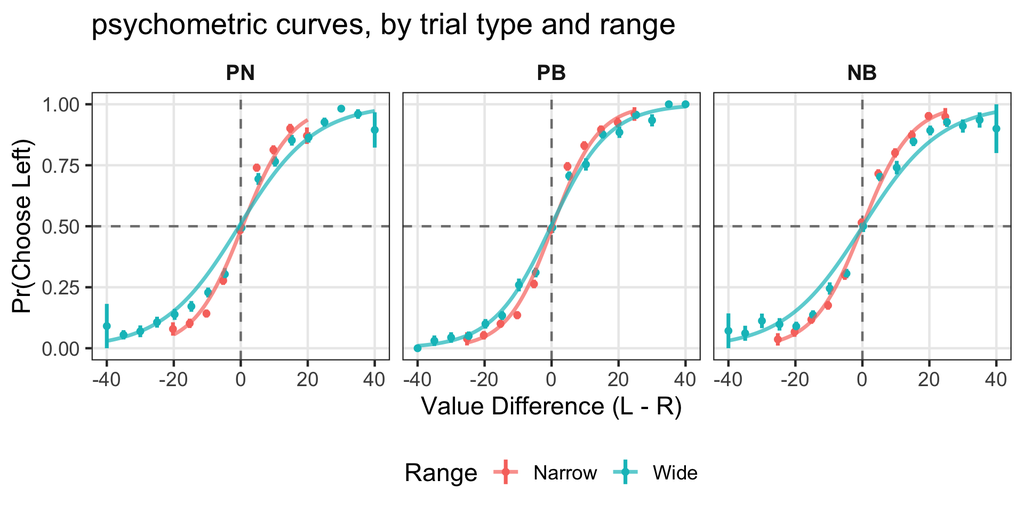

```r
pdata_choice = pas %>%
  group_by(Subject, BPN, WN, Diff) %>%
  summarize(
    y_subject = mean(ChooseL),
    .groups = "drop"
  ) %>%
  group_by(BPN, WN, Diff) %>%
  summarize(
    se = sd(y_subject) / sqrt(n()),
    y = mean(y_subject),
    .groups = "drop"
  )

ggplot(pdata_choice, aes(x = Diff, y = y, color = WN)) +
  facet_grid(. ~ BPN) +
  geom_vline(xintercept = 0, linetype = "dashed", color = "grey50") +
  geom_hline(yintercept = 0.5, linetype = "dashed", color = "grey50") +

  #geom_line(position = position_dodge(width = 1), linewidth = 1) +
  geom_pointrange(
    aes(ymin = y - se, ymax = y + se),
    size = .1,
    position = position_dodge(width = 1),
    linewidth = 1
  ) +
  stat_smooth(
    method = "glm",
    method.args = list(family = "binomial"),
    se = FALSE,
    geom = "line",
    alpha = 0.7,
    linewidth = 1
  ) +

  labs(
    x = "Value Difference (L - R)",
    y = "Pr(Choose Left)",
    color = "Range",
    title = "psychometric curves, by trial type and range"
  ) +
  theme(legend.position = "bottom")
```

## RT

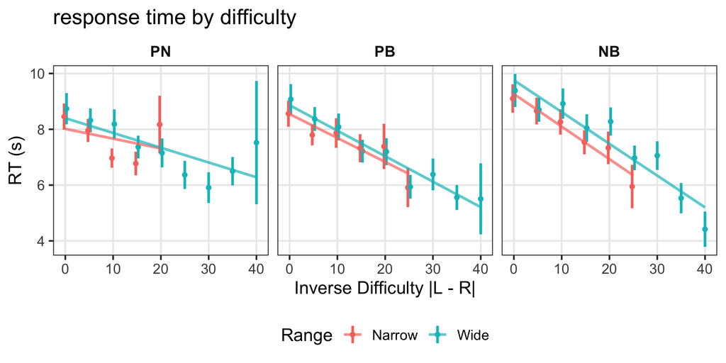

```r
pdata_rt <- pas %>%
  group_by(Subject, BPN, WN, Difficulty) %>%
  summarize(
    y_subject = mean(RT),
    .groups = "drop"
  ) %>%
  group_by(BPN, WN, Difficulty) %>%
  summarize(
    se = sd(y_subject) / sqrt(n()),
    y = mean(y_subject),
    .groups = "drop"
  )

ggplot(pdata_rt, aes(x = Difficulty, y = y, color = WN)) +
  facet_grid(. ~ BPN) +

  #geom_line(position = position_dodge(width = 1), linewidth = 1) +
  geom_pointrange(
    aes(ymin = y - se, ymax = y + se),
    size = .1,
    position = position_dodge(width = 1),
    linewidth = 1
  ) +
  stat_smooth(
    method = "lm",
    se = FALSE,
    geom = "line",
    alpha = 0.7,
    linewidth = 1
  ) +

  labs(
    x = "Inverse Difficulty |L - R|",
    y = "RT (s)",
    color = "Range",
    title = "response time by difficulty"
  ) +
  theme(legend.position = "bottom")
```

# Fixation Propoerties

## Fixation duration by box and condition

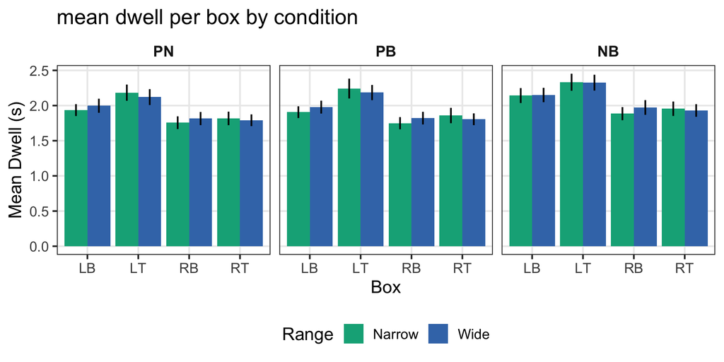

```r
prop_dat <- pas %>%
  group_by(Subject, BPN, WN) %>%
  summarise(across(c(DwellLT, DwellLB, DwellRT, DwellRB), \(x) mean(x, na.rm = TRUE)), .groups = "drop") %>%
  pivot_longer(c(DwellLT, DwellLB, DwellRT, DwellRB),
               names_to = "box", values_to = "mean_dwell") %>%
  mutate(box = str_remove(box, "Dwell")) %>%
  group_by(BPN, WN, box) %>%
  summarise(se = sd(mean_dwell, na.rm = TRUE) / sqrt(n()),
            mean_dwell = mean(mean_dwell, na.rm = TRUE),
            .groups = "drop")

pd <- position_dodge(0.9)

ggplot(prop_dat, aes(x = box, y = mean_dwell, fill = WN)) +
  facet_grid(. ~ BPN) +

  geom_col(position = pd) +
  geom_linerange(aes(ymin = mean_dwell - se, ymax = mean_dwell + se), position = pd, width = 0.25) +

  scale_fill_manual(values = plt$wn_colors) +
  labs(
    x = "Box",
    y = "Mean Dwell (s)",
    fill = "Range",
    title = "mean dwell per box by condition"
  ) +
  theme(legend.position = "bottom")
```

## Fixation duration by value

```r
dur_dat <- long %>%
  filter(FixDur > 0) %>%
  mutate(v = fix_value / 10)

dur_fit <- lmer(
  log(FixDur) ~ fix_type * v + (1 | Subject),
  data = dur_dat
)
summary(dur_fit)
```

```
## Linear mixed model fit by REML ['lmerMod']
## Formula: log(FixDur) ~ fix_type * v + (1 | Subject)
##    Data: dur_dat
##
## REML criterion at convergence: 964352.2
##
## Scaled residuals:
##     Min      1Q  Median      3Q     Max
## -5.3511 -0.2429  0.1432  0.4937  6.3675
##
## Random effects:
##  Groups   Name        Variance Std.Dev.
##  Subject  (Intercept) 0.2498   0.4998
##  Residual             1.1632   1.0785
## Number of obs: 321238, groups:  Subject, 981
##
## Fixed effects:
##              Estimate Std. Error t value
## (Intercept)  3.624162   0.017269 209.870
## fix_typeN   -0.021163   0.009173  -2.307
## fix_typeB    0.007076   0.007339   0.964
## v           -0.010134   0.002532  -4.003
## fix_typeN:v  0.007926   0.003656   2.168
## fix_typeB:v  0.006533   0.003725   1.754
##
## Correlation of Fixed Effects:
##             (Intr) fx_tyN fx_tyB v      fx_tN:
## fix_typeN   -0.263
## fix_typeB   -0.339  0.619
## v           -0.328  0.593  0.771
## fix_typeN:v  0.236  0.007 -0.554 -0.719
## fix_typeB:v  0.223 -0.403 -0.527 -0.680  0.490
```

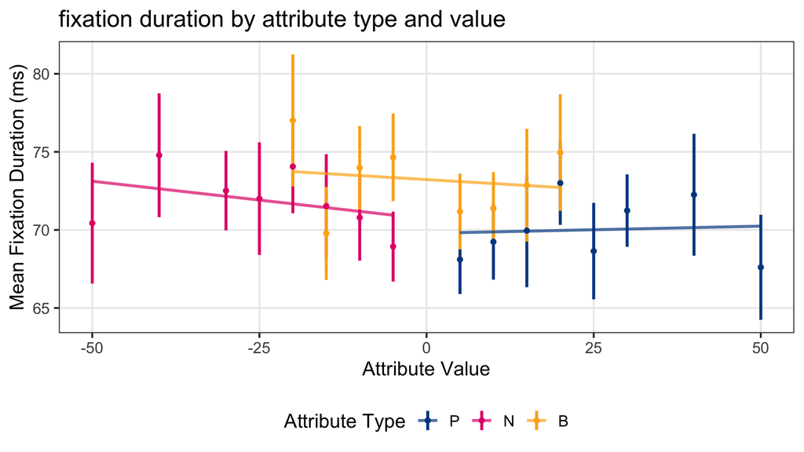

```r
pdata_dur <- dur_dat %>%
  group_by(Subject, fix_type, fix_value) %>%
  summarise(y_subject = mean(FixDur), .groups = "drop") %>%
  group_by(fix_type, fix_value) %>%
  summarise(
    se       = sd(y_subject) / sqrt(n()),
    mean_dur = mean(y_subject),
    .groups = "drop"
  )

ggplot(pdata_dur, aes(x = fix_value, y = mean_dur, color = fix_type)) +
  geom_pointrange(
    aes(ymin = mean_dur - se, ymax = mean_dur + se),
    size = .1,
    linewidth = 1
  ) +
  stat_smooth(
    method = "lm",
    se = FALSE,
    geom = "line",
    alpha = 0.7,
    linewidth = 1
  ) +
  scale_color_manual(values = plt$type_colors) +
  labs(x = "Attribute Value", y = "Mean Fixation Duration (ms)", color = "Attribute Type",
       title = "fixation duration by attribute type and value") +
  theme(legend.position = "bottom")
```

## Refixations by type and value

```r
count_fit <- glmmTMB(
  n_fix ~ type * v + offset(log(n_trial)) + (1 | Subject),
  data = box_grid, family = nbinom2
)
summary(count_fit)
```

[output not shown]

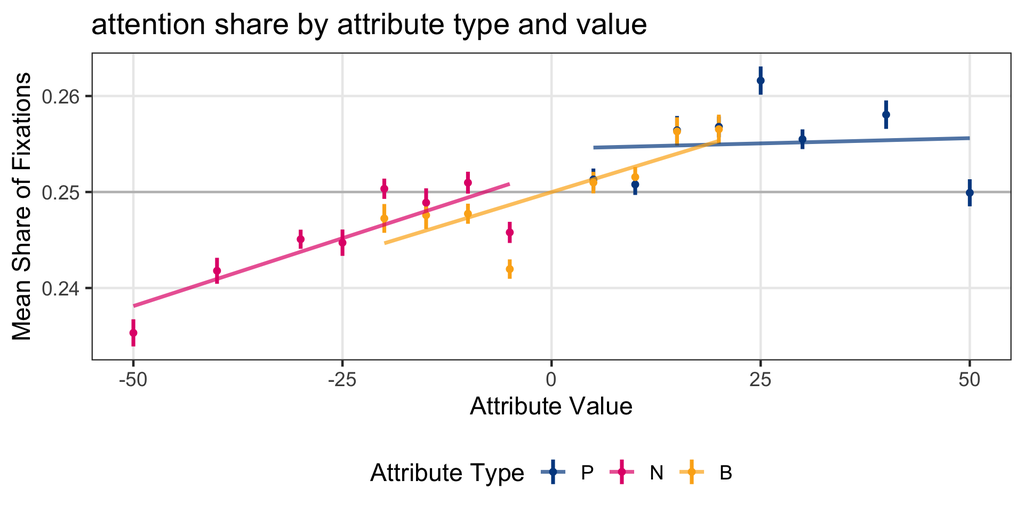

```r
pdata_box_grid = box_grid %>%
  group_by(Subject, type, value) %>%
  summarise(share = mean(n_fix / n_trial), .groups = "drop") %>%
  group_by(type, value) %>%
  summarise(
    se         = sd(share) / sqrt(n()),
    mean_share = mean(share),
    .groups = "drop"
  )

ggplot(pdata_box_grid, aes(x = value, y = mean_share, color = type)) +
  geom_hline(yintercept = 0.25, color = "grey") +
  geom_pointrange(
    aes(ymin = mean_share - se, ymax = mean_share + se),
    size = .1,
    linewidth = 1
  ) +
  stat_smooth(
    method = "lm",
    se = FALSE,
    geom = "line",
    alpha = 0.7,
    linewidth = 1
  ) +
  scale_color_manual(values = plt$type_colors) +
  labs(
    x = "Attribute Value",
    y = "Mean Share of Fixations",
    color = "Attribute Type",
    title = "attention share by attribute type and value"
  ) +
  theme(legend.position = "bottom")
```

# Option-Level Attention

## Net Fixation Bias

```r
opt_fit <- glmmTMB(
  ChooseL ~ Diff_z * DwellDiff_norm + (1 + Diff_z | Subject),
  data = pas, family = binomial
)
summary(opt_fit)
```

```
##  Family: binomial  ( logit )
## Formula:          ChooseL ~ Diff_z * DwellDiff_norm + (1 + Diff_z | Subject)
## Data: pas
##
##       AIC       BIC    logLik -2*log(L)  df.resid
##   27999.8   28057.5  -13992.9   27985.8     28150
##
## Random effects:
##
## Conditional model:
##  Groups  Name        Variance Std.Dev. Corr
##  Subject (Intercept) 0.01509  0.1228
##          Diff_z      0.53435  0.7310   -0.16
## Number of obs: 28157, groups:  Subject, 981
##
## Conditional model:
##                       Estimate Std. Error z value Pr(>|z|)
## (Intercept)           -0.06121    0.01623   -3.77 0.000163 ***
## Diff_z                 1.91296    0.03705   51.63  < 2e-16 ***
## DwellDiff_norm         1.21932    0.06569   18.56  < 2e-16 ***
## Diff_z:DwellDiff_norm  0.26378    0.09382    2.81 0.004931 **
## ---
## Signif. codes:  0 '***' 0.001 '**' 0.01 '*' 0.05 '.' 0.1 ' ' 1
```

# Attribute-Level Attention

We estimate a **signed attention weight**: the effect of one second of dwell on a box, on the log-odds of choosing that box’s option, holding value difference constant.

A positive weight means attention is associated with choosing the attended option. A negative weight is associated with choosing against the attended option.